# Human activity analysis

### Overview

This report uses the Weightlifting exercise dataset to build a model that predicts the manner in which 6 participants do a particular dumbell exercise. The data was obtained from http://groupware.les.inf.puc-rio.br/har.

### Description of the approach

**Cleaning Data:** An exploration of the training data shows that there are many columns that have a large number of NA values. These columns were removed from the training set. Additionally, fields like the index field (X), time stamp fields were also removed as they have no relevance to the analysis. The user_name field was also removed as it reflected the structure we were trying to predict. The cleaned dataset had 53 columns.

**Creating a validation set:** 25% of the training set was set aside as a validation set.

**Model fitting - Decision Tree:** Since the response variable has five possible categorical outcomes, a decision tree model was attempted. The model did not yeild good results. The decision tree is shown below. The predicted values on the validation set are compared to the actual values below, showing quite a bit of divergence between the predictions and actual values.

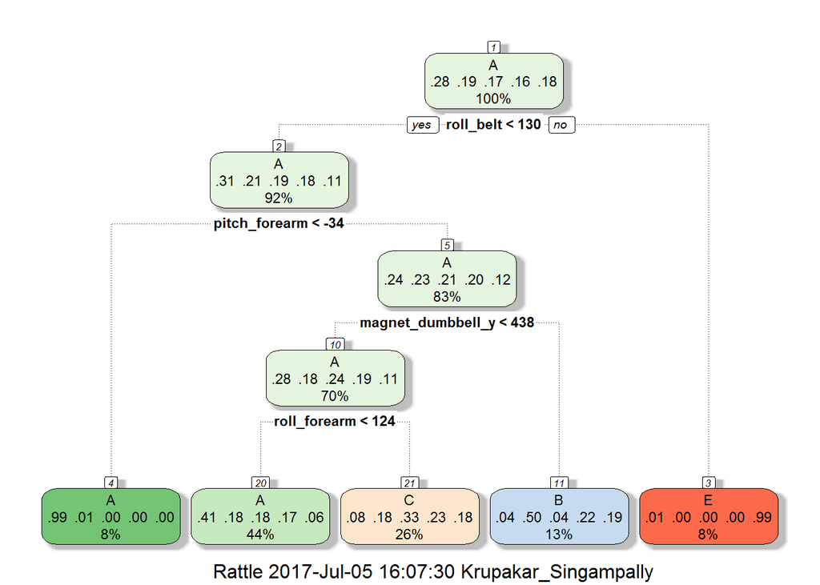

```
##
## wtdtpred    A    B    C    D    E
##        A 1261  385  405  361  140
##        B   22  325   24  145  121
##        C  106  239  426  298  247
##        D    0    0    0    0    0
##        E    6    0    0    0  393
```

**Model fitting - Boosting model:** A gradient boosting model was applied with cross validation of the training data, yielding high accuracy.

```
## Stochastic Gradient Boosting
##
## 14718 samples
##    52 predictor
##     5 classes: 'A', 'B', 'C', 'D', 'E'
##
## No pre-processing
## Resampling: Cross-Validated (10 fold)
## Summary of sample sizes: 13247, 13247, 13246, 13248, 13246, 13247, ...
## Resampling results across tuning parameters:
##
##   interaction.depth  n.trees  Accuracy   Kappa
##   1                   50      0.7528213  0.6867082
##   1                  100      0.8205632  0.7728773
##   1                  150      0.8565041  0.8183921
##   2                   50      0.8559606  0.8175225
##   2                  100      0.9057639  0.8807486
##   2                  150      0.9309695  0.9126451
##   3                   50      0.8950295  0.8671157
##   3                  100      0.9400747  0.9241669
##   3                  150      0.9615439  0.9513479
##
## Tuning parameter 'shrinkage' was held constant at a value of 0.1
##
## Tuning parameter 'n.minobsinnode' was held constant at a value of 10
## Accuracy was used to select the optimal model using  the largest value.
## The final values used for the model were n.trees = 150,
##  interaction.depth = 3, shrinkage = 0.1 and n.minobsinnode = 10.
```

```
## Confusion Matrix and Statistics
##
##           Reference
## Prediction    A    B    C    D    E
##          A 1371   42    0    1    5
##          B   16  878   28    4   13
##          C    5   28  816   27    5
##          D    3    1   11  768    8
##          E    0    0    0    4  870
##
## Overall Statistics
##
##                Accuracy : 0.959
##                  95% CI : (0.9531, 0.9644)
##     No Information Rate : 0.2845
##     P-Value [Acc > NIR] : < 2.2e-16
##
##                   Kappa : 0.9481
##  Mcnemar's Test P-Value : 2.136e-07
##
## Statistics by Class:
##
##                      Class: A Class: B Class: C Class: D Class: E
## Sensitivity            0.9828   0.9252   0.9544   0.9552   0.9656
## Specificity            0.9863   0.9846   0.9839   0.9944   0.9990
## Pos Pred Value         0.9662   0.9350   0.9262   0.9709   0.9954
## Neg Pred Value         0.9931   0.9821   0.9903   0.9912   0.9923
## Prevalence             0.2845   0.1935   0.1743   0.1639   0.1837
## Detection Rate         0.2796   0.1790   0.1664   0.1566   0.1774
## Detection Prevalence   0.2894   0.1915   0.1796   0.1613   0.1782
## Balanced Accuracy      0.9846   0.9549   0.9692   0.9748   0.9823
```

**Model fitting - Random Forest:** A random forest algorithm with 50 trees gave good results when tested on the validation set. The model is described below:

```
##
## Call:
##  randomForest(formula = classe ~ ., data = wttrain_final, ntree = 50)
##                Type of random forest: classification
##                      Number of trees: 50
## No. of variables tried at each split: 7
##
##         OOB estimate of  error rate: 0.62%
## Confusion matrix:
##      A    B    C    D    E  class.error
## A 4181    4    0    0    0 0.0009557945
## B   18 2819    9    1    1 0.0101825843
## C    0   14 2548    5    0 0.0074016362
## D    1    0   30 2380    1 0.0132669983
## E    0    1    1    5 2699 0.0025868441
```

The variables that have the highest priority in the model are seen in the plot below.

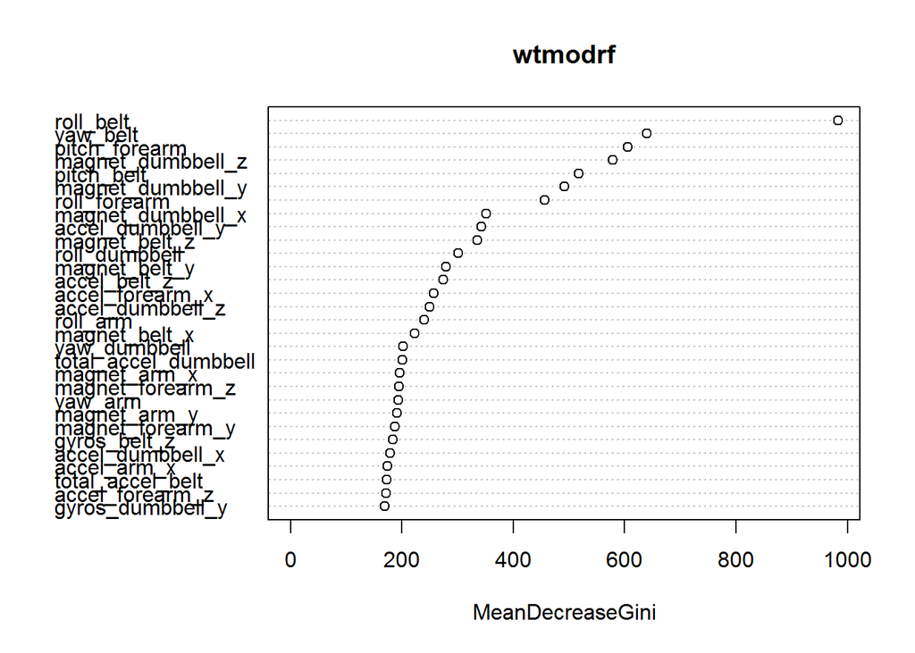

The model is used to predict against the validation set, and the results are tabulated below, showing a high degree of agreement between the forecast and results.

```
##
## wtrfpred    A    B    C    D    E
##        A 1394    7    0    0    0
##        B    0  939    3    0    0
##        C    0    3  851    6    0
##        D    0    0    1  796    1
##        E    1    0    0    2  900
```

**Conclusion**: The gbm model gives good accuracy but the random forest model is the winner with higher accuracy.